# 2 R中回归分析之一：一元回归及分组回归

Li Zongzhang

2022-9-22

本章介绍R中的回归分析工具。

数据：ggplot2包中的mpg

请先加载以下包。

```r
#安装包,下述命令运行时，需要把#删掉，再运行。
#已经装过的包，不用再重复安装
#install.packages("nlme")
#install.packages("readr")
#install.packages("readxl")
#install.package("gplot2")
##install.package("tidyberse")

#加载包
library(readr)
library(readxl)
library(nlme)
library(ggplot2)
library(tidyverse)


#调用数据mpg
data(mpg)
```

# 1 一元回归

## 1.1 散点图上添加拟合线

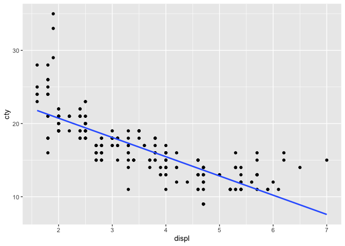

```r
#geom_smooth()添加回归线，method = lm 线性回归
mpg %>%
  ggplot(aes(displ, cty))+
  geom_point()+
  geom_smooth(method = lm,
              se = F)
```

## 1.2 散点图上添加二阶曲线

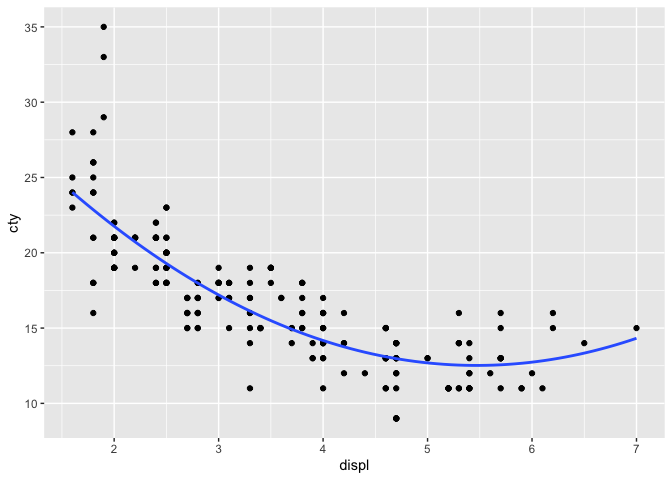

```r
#添加二阶曲线
mpg %>%
  ggplot(aes(displ, cty))+
  geom_point()+
  geom_smooth(method = lm,
              se = F,
              formula = y ~ poly(x,2))+
  theme()
```

## 1.3 散点图添加主题，设置字体和颜色

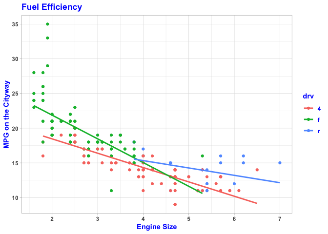

```r
#添加主题，设置字体和颜色
mpg %>%
  ggplot(aes(displ, cty,
             color = drv))+
  geom_point()+
  geom_smooth(method = lm,
              se = F)+
  labs(x = "Engine Size",
       y = "MPG on the Cityway",
       title = "Fuel Efficiency")+
  theme_light()+
  theme(text = element_text(face = "bold",
                            color = "blue"))
```

## 1.4 参数估计lm()

```r
#写法一
lm(mpg$cty ~ mpg$displ)
```

```
##
## Call:
## lm(formula = mpg$cty ~ mpg$displ)
##
## Coefficients:
## (Intercept)    mpg$displ
##       25.99        -2.63
```

```r
#写法二
lm(cty ~ displ, mpg)
```

```
##
## Call:
## lm(formula = cty ~ displ, data = mpg)
##
## Coefficients:
## (Intercept)        displ
##       25.99        -2.63
```

```r
#写法三
# 数据mpg被pipe到lm函数的第2项参数，"."代表占位符placeholder
mpg %>% lm(cty ~ displ, .)
```

```
##
## Call:
## lm(formula = cty ~ displ, data = .)
##
## Coefficients:
## (Intercept)        displ
##       25.99        -2.63
```

## 1.5 报告回归模型详细结果summary()

```r
#写法一
model1 <- lm(mpg$hwy ~ mpg$displ)
summary(model1)
```

```
##
## Call:
## lm(formula = mpg$hwy ~ mpg$displ)
##
## Residuals:
##     Min      1Q  Median      3Q     Max
## -7.1039 -2.1646 -0.2242  2.0589 15.0105
##
## Coefficients:
##             Estimate Std. Error t value Pr(>|t|)
## (Intercept)  35.6977     0.7204   49.55   <2e-16 ***
## mpg$displ    -3.5306     0.1945  -18.15   <2e-16 ***
## ---
## Signif. codes:  0 '***' 0.001 '**' 0.01 '*' 0.05 '.' 0.1 ' ' 1
##
## Residual standard error: 3.836 on 232 degrees of freedom
## Multiple R-squared:  0.5868, Adjusted R-squared:  0.585
## F-statistic: 329.5 on 1 and 232 DF,  p-value: < 2.2e-16
```

```r
#写法二
library(tidyverse)

mpg %>%
  lm(hwy ~ displ, .) %>%
  summary()
```

```
##
## Call:
## lm(formula = hwy ~ displ, data = .)
##
## Residuals:
##     Min      1Q  Median      3Q     Max
## -7.1039 -2.1646 -0.2242  2.0589 15.0105
##
## Coefficients:
##             Estimate Std. Error t value Pr(>|t|)
## (Intercept)  35.6977     0.7204   49.55   <2e-16 ***
## displ        -3.5306     0.1945  -18.15   <2e-16 ***
## ---
## Signif. codes:  0 '***' 0.001 '**' 0.01 '*' 0.05 '.' 0.1 ' ' 1
##
## Residual standard error: 3.836 on 232 degrees of freedom
## Multiple R-squared:  0.5868, Adjusted R-squared:  0.585
## F-statistic: 329.5 on 1 and 232 DF,  p-value: < 2.2e-16
```

```r
#查看model1中保存的对象的名称
attributes(model1)
```

```
## $names
##  [1] "coefficients"  "residuals"     "effects"       "rank"
##  [5] "fitted.values" "assign"        "qr"            "df.residual"
##  [9] "xlevels"       "call"          "terms"         "model"
##
## $class
## [1] "lm"
```

```r
#model1$residuals

model1$coefficients
```

```
## (Intercept)   mpg$displ
##   35.697651   -3.530589
```

```r
#model1$fitted.values


#查看summary(model1)中保存的对象名称
model1_summary <- summary(model1)
attributes(model1_summary)
```

```
## $names
##  [1] "call"          "terms"         "residuals"     "coefficients"
##  [5] "aliased"       "sigma"         "df"            "r.squared"
##  [9] "adj.r.squared" "fstatistic"    "cov.unscaled"
##
## $class
## [1] "summary.lm"
```

## 1.6 散点图标注回归方程

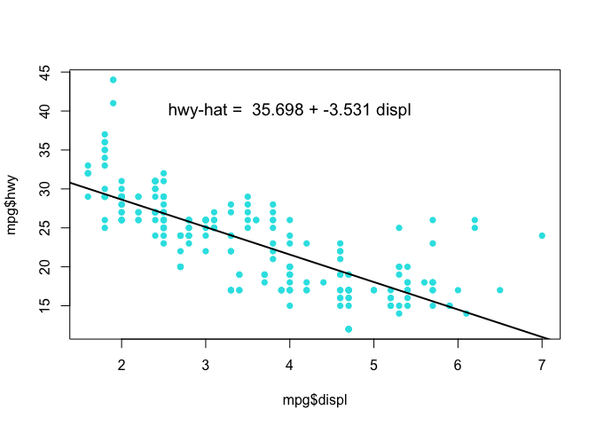

```r
#plot()绘制散点图， 设置点的形状point character, pch=; 设置点的颜色 col =
plot(mpg$displ, mpg$hwy, pch = 16, col = 5)

#Add Straight Lines to a Plot
abline(lm(mpg$hwy ~ mpg$displ), col = 9, lwd = 2)

#将lm(mpg$hwy ~ mpg$displ)的系数保留3位小数，保存到对象coef中
coef <- round(coef(lm(mpg$hwy ~ mpg$displ)), 3)

#text()在图中添加文本
#4，40代表添加的文本在图形中的横纵坐标
#paste()生成回归方程的表达式
#cex = 1.2 , character expansion, 代表相对于默认字体放大的倍数
text(4, 40,  paste("hwy-hat = ", coef[1], "+", coef[2], "displ"), cex = 1.2)
```

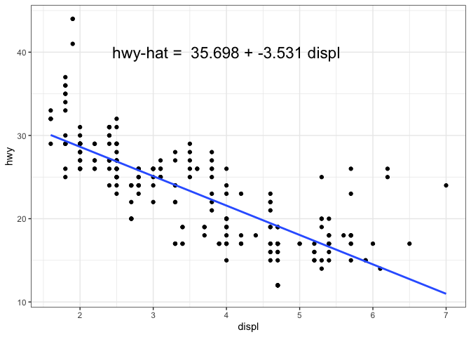

```r
#方法二：ggplot中添加
mpg %>%
  ggplot(aes(displ, hwy))+
  geom_point()+
  geom_smooth(method = lm, se = F) +
  annotate("text", x = 4, y =40,
           label = paste("hwy-hat = ", coef[1], "+", coef[2], "displ"), size = 6)+
  theme_bw()
```

# 2 分组回归

## 2.1 分组散点图及添加分组回归线

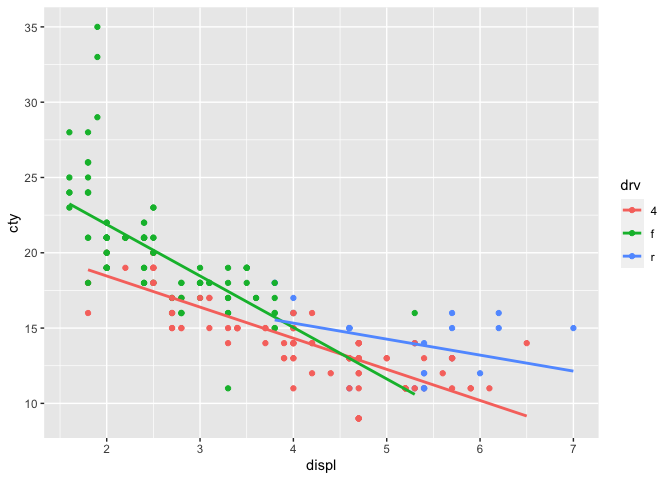

```r
# ggplot(aes(displ, cty,
#             color = drv))对画布上所有的图层生效

mpg %>%
  ggplot(aes(displ, cty,
             color = drv))+
  geom_point()+
  geom_smooth(method = lm,
              se = F)
```

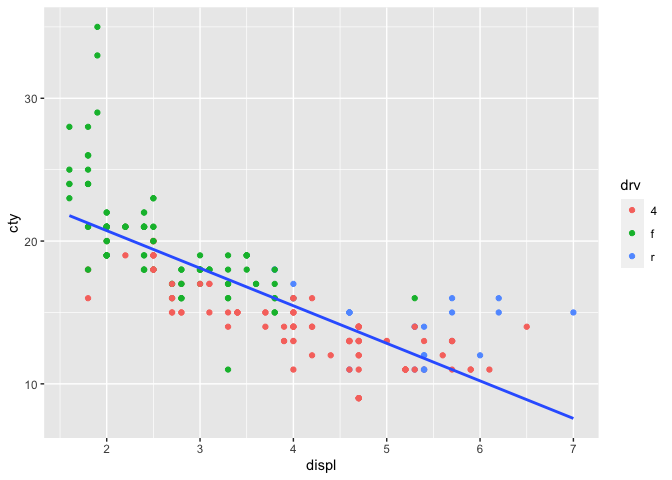

```r
# 对比：将aes(color = drv)写在geom_point()中
#geom_point(aes(color = drv)) color只对点生效
mpg %>%
  ggplot(aes(displ, cty))+
  geom_point(aes(color = drv))+
  geom_smooth(method = lm,
              se = F)
```

## 2.2 在变量名后用[]设定条件

```r
model4cyl <- lm(mpg$cty[mpg$cyl == 4] ~
                  mpg$displ[mpg$cyl == 4])
summary(model4cyl)
```

```
##
## Call:
## lm(formula = mpg$cty[mpg$cyl == 4] ~ mpg$displ[mpg$cyl == 4])
##
## Residuals:
##     Min      1Q  Median      3Q     Max
## -7.0733 -1.7074 -0.2658  1.1002 12.5229
##
## Coefficients:
##                         Estimate Std. Error t value Pr(>|t|)
## (Intercept)               33.805      2.285  14.794  < 2e-16 ***
## mpg$displ[mpg$cyl == 4]   -5.962      1.054  -5.658 2.37e-07 ***
## ---
## Signif. codes:  0 '***' 0.001 '**' 0.01 '*' 0.05 '.' 0.1 ' ' 1
##
## Residual standard error: 2.97 on 79 degrees of freedom
## Multiple R-squared:  0.2883, Adjusted R-squared:  0.2793
## F-statistic: 32.01 on 1 and 79 DF,  p-value: 2.367e-07
```

```r
model6cyl <- lm(mpg$cty[mpg$cyl == 6] ~
                  mpg$displ[mpg$cyl == 6])
summary(model6cyl)
```

```
##
## Call:
## lm(formula = mpg$cty[mpg$cyl == 6] ~ mpg$displ[mpg$cyl == 6])
##
## Residuals:
##     Min      1Q  Median      3Q     Max
## -5.4057 -1.2057 -0.1807  1.0693  2.9443
##
## Coefficients:
##                         Estimate Std. Error t value Pr(>|t|)
## (Intercept)              22.1805     1.3055  16.990  < 2e-16 ***
## mpg$displ[mpg$cyl == 6]  -1.7499     0.3794  -4.612 1.56e-05 ***
## ---
## Signif. codes:  0 '***' 0.001 '**' 0.01 '*' 0.05 '.' 0.1 ' ' 1
##
## Residual standard error: 1.58 on 77 degrees of freedom
## Multiple R-squared:  0.2165, Adjusted R-squared:  0.2063
## F-statistic: 21.27 on 1 and 77 DF,  p-value: 1.557e-05
```

```r
model8cyl <- lm(mpg$cty[mpg$cyl == 8] ~
                  mpg$displ[mpg$cyl == 8])
summary(model8cyl)
```

```
##
## Call:
## lm(formula = mpg$cty[mpg$cyl == 8] ~ mpg$displ[mpg$cyl == 8])
##
## Residuals:
##    Min     1Q Median     3Q    Max
## -3.386 -1.600  0.185  1.357  3.829
##
## Coefficients:
##                         Estimate Std. Error t value Pr(>|t|)
## (Intercept)              10.3674     1.9017   5.452  7.5e-07 ***
## mpg$displ[mpg$cyl == 8]   0.4294     0.3681   1.166    0.248
## ---
## Signif. codes:  0 '***' 0.001 '**' 0.01 '*' 0.05 '.' 0.1 ' ' 1
##
## Residual standard error: 1.802 on 68 degrees of freedom
## Multiple R-squared:  0.01962,    Adjusted R-squared:  0.005199
## F-statistic: 1.361 on 1 and 68 DF,  p-value: 0.2475
```

## 2.3 nlme::lmList()

```r
#install.packages("nlme")
library(nlme)

modelbycyl <- lmList(cty ~ displ | cyl, data = mpg)
modelbycyl
```

```
## Call:
##   Model: cty ~ displ | cyl
##    Data: mpg
##
## Coefficients:
##   (Intercept)      displ
## 4    33.80529 -5.9621902
## 5    20.50000         NA
## 6    22.18050 -1.7499416
## 8    10.36745  0.4293868
##
## Degrees of freedom: 234 total; 226 residual
## Residual standard error: 2.21685
```

```r
attributes(modelbycyl)
```

```
## $names
## [1] "4" "5" "6" "8"
##
## $class
## [1] "lmList"
##
## $dims
## $dims$N
## [1] 234
##
## $dims$M
## [1] 4
##
##
## $call
## lmList.formula(object = cty ~ displ | cyl, data = mpg)
##
## $groupsForm
## ~cyl
##
## $groups
##   [1] 4 4 4 4 6 6 6 4 4 4 4 6 6 6 6 6 6 8 8 8 8 8 8 8 8 8 8 8 8 8 8 8 4 4 6 6 6
##  [38] 4 6 6 6 6 6 6 6 6 6 6 6 6 6 6 8 8 8 8 8 6 8 8 8 8 8 8 8 8 8 8 8 8 8 8 8 8
##  [75] 8 8 8 6 6 6 6 8 8 6 6 8 8 8 8 8 6 6 6 6 8 8 8 8 8 4 4 4 4 4 4 4 4 4 4 4 4
## [112] 4 6 6 6 4 4 4 4 6 6 6 6 6 6 8 8 8 8 8 8 8 8 8 8 8 8 6 6 8 8 4 4 4 4 6 6 6
## [149] 6 6 6 6 6 8 6 6 6 6 8 4 4 4 4 4 4 4 4 4 4 4 4 4 4 4 4 6 6 6 8 4 4 4 4 6 6
## [186] 6 4 4 4 4 6 6 6 4 4 4 4 4 8 8 4 4 4 6 6 6 6 4 4 4 4 6 4 4 4 4 4 5 5 6 6 4
## [223] 4 4 4 5 5 4 4 4 4 6 6 6
## Levels: 4 < 5 < 6 < 8
##
## $origOrder
## [1] 1 3 4 2
##
## $level
## [1] 1
##
## $pool
## [1] TRUE
```

```r
summary(modelbycyl)$r.squared
```

```
## [1] 0.28834270 0.00000000 0.21648101 0.01961665
```

# 3 本章作业

**将代码和输出结果转成图片，上传至91速课平台。**

## 3.1 习题1

**数据文件: mtcars**

要求：

1.1.建立mpg和wt的一元线性回归模型，报告估计结果。

1.2.建立mpg和hp的一元线性回归模型，报告估计结果。

1.3.根据vs将样本分为两组，对两个组别分别建立mpg和wt的一元线性回归模型，报告估计结果。

1.4.根据vs将样本分为两组，对两个组别分别建立mpg和hp的一元线性回归模型，报告估计结果。

## 3.2 习题2

**数据：教材P38,2.19**

要求：

2.1. 报告表2-14中价格、年代、投标人数的均值、标准差、中位数、最大值和最小值。

2.2 绘制价格和年代的散点图，添加回归线。

2.3 绘制价格和投标人数的散点图，添加回归线。

2.4 建立价格和年代的一元线性回归模型，报告估计结果。

2.5 建立价格和投标人数的一元线性回归模型，报告估计结果。